# Data manipulation with `dplyr`

Data Science for Biologists, Spring 2020

Stephanie J. Spielmam

## Resources

Your resources for working with `dplyr` include:

1. [dplyr documentation](http://rmarkdown.rstudio.com)
2. [dplyr Cheatsheet](https://github.com/rstudio/cheatsheets/blob/master/data-transformation.pdf)
3. [The dplyr Vignette](https://dplyr.tidyverse.org/articles/dplyr.html)

Remember this table of the most common (plus some of my favorite) `dplyr` verbs (functions), and remember the **pipe** operator `%>%` for automatically sending output to a new function as input:

| Function | Purpose | Example |
| --- | --- | --- |
| `select()` | Select or remove certain **columns** (variables) from a tibble | `select(iris, Petal.Width) ## Keep only Petal.Width` `iris %>% select(Petal.Width)` `iris %>% select(-Petal.Width) ## Remove column Petal Width` |
| `filter()` | Subset certain **rows** (observations/cases) from a tibble using a logical expression | `filter(iris, Petal.Width <= 2)` `iris %>% filter(Petal.Width <= 2)` `iris %>% filter(Species == "setosa")` |
| `mutate()` | Create a new column (variable) | `mutate(iris, petal_area = Petal.Width * Petal.Length)` `iris %>% mutate(petal_area = Petal.Width * Petal.Length)` `iris %>% mutate(flower_type = "iris")` |
| `summarize()` | Reduce multiple rows to a single *summarized* row/set of rows (observations) | `summarize(iris, mean_petal_width = mean(Petal.Width))` `iris %>% summarize(mean_petal_width = mean(Petal.Width))` |
| `group_by()` | Specify a grouping for grouped operations | `## Calculate the mean for each Species` `iris %>%` `group_by(Species) %>%` `summarize(mean_petal_width = mean(Petal.Width))` |
| `ungroup()` | Clear a tibble of all groupings. *Recommended after done with `group_by()` operations!!* | `iris %>%` `group_by(Species) %>%` `summarize(mean_petal_width = mean(Petal.Width)) %>%` `ungroup()` |
| `tally()` | Short-cut to create a new column `n` with *counts per group* | `## add a column "n" with the number of each Species in data.` `iris %>%` `group_by(Species) %>%` `tally()` |
| `count()` | Short-cut of `group_by(...) %>% tally() %>% ungroup()` | `# Equivalent to the tally() example above (except also ungroups it! very helpful!)` `iris %>% count(Species)` |

> NOTE: *Many* packages in R have a function called `select()` including base R, so it is not unusual for R to get confused which `select()` you are trying to use (later on we will learn where this confusion comes from). If you ever see an error that `select()` isn’t working as you expect, re-write it explicitly as `dplyr::select()` to clearly tell R that you want the `dplyr` function.

## Setup

We will learn the fundamentals of `dplyr` using the built-in R dataset `CO2`. This dataset is not in the best default format, so we will define it as a tibble for our use, **but save it as a new variable `CO2_tibble`**.

```r
# Create a new lowercase variable. __NEVER__ overwrite base R variables.
# CO2 <- as.tibble(CO2) is _very bad._ Don't do this.
CO2_tibble <- as_tibble(CO2)
head(CO2_tibble)
```

```
## # A tibble: 6 x 5
##   Plant Type   Treatment   conc uptake
##   <ord> <fct>  <fct>      <dbl>  <dbl>
## 1 Qn1   Quebec nonchilled    95   16
## 2 Qn1   Quebec nonchilled   175   30.4
## 3 Qn1   Quebec nonchilled   250   34.8
## 4 Qn1   Quebec nonchilled   350   37.2
## 5 Qn1   Quebec nonchilled   500   35.3
## 6 Qn1   Quebec nonchilled   675   39.2
```

This dataset contains “data from an experiment on the cold tolerance of the grass species *Echinochloa crus-galli*…. The CO2 uptake of six plants from Quebec and six plants from Mississippi was measured at several levels of ambient CO2 concentration. Half the plants of each type were chilled overnight before the experiment was conducted.”

### Messages from `tidylog`

To assist in learning `dplyr` (and more packages coming soon), we will also be using the (pre-installed for you) library, `tidylog`. As you can see in the setup R chunk of this document, `tidylog` has been loaded for you. This fairly amazing library provides you with direct feedback about what goes on “under the hood” of `tidyverse` operations.

```r
## Obtain all rows where the plant is from Quebec
CO2_tibble %>%
  filter(Type == "Quebec")
```

```
## filter: removed 42 rows (50%), 42 rows remaining
```

```
## # A tibble: 42 x 5
##    Plant Type   Treatment   conc uptake
##    <ord> <fct>  <fct>      <dbl>  <dbl>
##  1 Qn1   Quebec nonchilled    95   16
##  2 Qn1   Quebec nonchilled   175   30.4
##  3 Qn1   Quebec nonchilled   250   34.8
##  4 Qn1   Quebec nonchilled   350   37.2
##  5 Qn1   Quebec nonchilled   500   35.3
##  6 Qn1   Quebec nonchilled   675   39.2
##  7 Qn1   Quebec nonchilled  1000   39.7
##  8 Qn2   Quebec nonchilled    95   13.6
##  9 Qn2   Quebec nonchilled   175   27.3
## 10 Qn2   Quebec nonchilled   250   37.1
## # … with 32 more rows
```

Because we loaded `tidylog`, we were given this added output information :`## filter: removed 42 rows (50%), 42 rows remaining`.

## EXERCISE SET ONE

Perform all exercises using the `%>%` operator. You will probably type it as `>%>` sometimes, so expect this bug ;)

##### Question 1

Subset the data using `filter()` to contain only observations from Mississippi (Hint: make sure to spell it right!).

##### Question 2

Subset the data using `filter()` to contain only observations from Mississippi exposed to chilled environment. Hint: You can provide multiple logical statements to `filter()` simply by separating them by commas. This is assumed to mean “and”.

##### Question 3

Subset the data using `filter()` to contain only observations from Mississippi exposed to chilled environment, and *then* keep only rows `Plant`, `Type`, and `Treatment`.

##### Question 4

Remove the columns `Update` and `Conc` from the data using `select()`. In your code, refer only to these two column names - NOT `Plant`, `Type`, etc.

##### Question 5

Subset the data using `select()` to contain only observations where the plant is either `Qn1` or `Qn2`. using the `%in%` operator (remember this?) to ask whether `Plant` is *in* an array of these plants, i.e. `c("Qn1", "Qn2")`

##### Question 6

Subset the data using `filter()` to contain only rows where uptake is greater than or equal to 38.

##### Question 7

Create a *new column* using `mutate()` called “new_column” where all rows have the value 5.

##### Question 8

CO2 concentration in this dataset is measured in mL/L - let’s change the units to cL/L (i.e. milli -> centi by dividing by 10). Create a new column using `mutate()` called “conc_cLL” using `mutate()` which contains the concentration measured in cL/L.

##### Question 9

Modify your answer to #8 by, at the end, removing the original `uptake` column. Save the final result to a new tibble `CO2_tibble2` and examine its output with `head()` to confirm your it all worked.

##### Question 10

Create a new column using `mutate()` called “high_uptake”. Rows where uptake is *greater than or equal to 38* are considered to have high uptakes. Rows with high uptake should be given the value `TRUE`, and `FALSE` otherwise. Hint: Most of the code is identical to your solution to #6!

##### Question 11

Calculate the mean uptake as a new column. Do this in two ways: first with `mutate()` and then with `summarize()`. Examine the difference between your outputs to understand the difference between these two `dplyr` verbs.

##### Question 12

Create a new tibble called “quebec” that contains *only* plants from Quebec. Work with this tibble to determine the following:

- What is the mean (function `mean()`) uptake for Quebec plants? **Use `summarize()`**, no dollar signs!
- What is the mean uptake for all *chilled* Quebec plants? Again use `summarize()`, but first you’ll want to filter the data for only chilled plants.
- Without filtering, use a single chain of commands to determine the mean uptake for both chilled and nonchilled Quebec plants. You’ll need to use `group_by()` to setup `summarize()` to do calculations separately for these two groups.
- What is the median (function `median()`) uptake for Quebec plants?
- What is the median uptake for Quebec plants exposed to a concentration of 500 mL/L?
- What is the median update for chilled and nonchilled Quebec plants separately exposed to a concentration of 500 mL/L?
- How many plants have an uptake less than 25 when exposed to a CO2 concentration of 500 mL/L? You can answer this by piping your commands into `tally()` but without grouping the data - `dplyr` will assume all data is one group, and simply count the the number of rows!

##### Question 13

Let’s now compare plants from Mississippi to those from Quebec in *one chain of commands*: Which plant type has a higher mean uptake, considering only nonchilled plants exposed to a concentration of 1000 mL/L?

This is a fairly involved question with multiple steps, so let’s break it down: Generally speaking, it is always a good first step to subset the data to only those observations we’re interested in. Here, we’re only interested in nonchilled plants exposed to 1000 mL/L. Then we can perform operations on the subsetted data, which is to calculate the mean uptake (sounds like a *summary*!) for plants in Mississippi and Quebec separately (these sound like *groups* we should summarize separately!).

For involved tasks like this, **YOU REALLY REALLY REALLY SHOULD** to do each step one at a time, examine its output, and then proceed to tack on the next step.

##### Question 14

Now seems as good a time as any to introduce line plots! Together, we will learn how to create the plot shown below. We will also discuss whether the points as shown are a good idea or not.

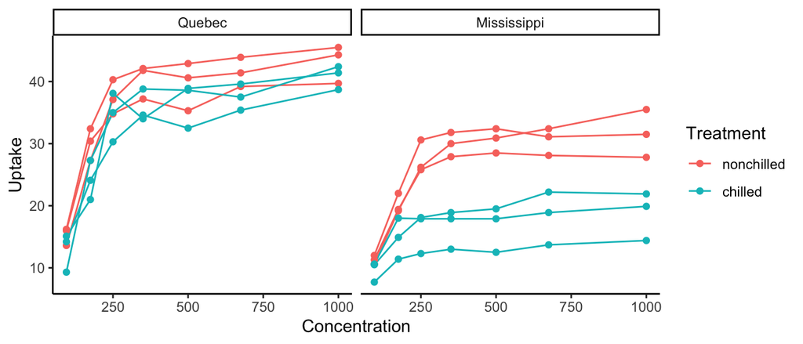